# Supplementary Materials: GP Surrogates for Option Prices and Greeks

Mike Ludkovski, Jimmy Risk

04/15/2024

This RMarkdown file presents an illustrative use of Gaussian Process surrogates for estimation of option prices and sensitivities, linking to **Chapter 5** of the book. We directly embed `R` code snippets to showcase the straightforward use of the methodology.

# Section 5.1: Learning a univariate Heston Pricing Formula

As the first example, we illustrate building a GP model to learn the Heston Pricing formula for Calls. The included CSV file contains a matrix of Calls index by maturity date $T$ and strikes ${\cal K}$.

```r
df_Calls <- read.csv("HestonPrices.csv")
```

We fix $S_0$ and learn the input-output map
$$T \mapsto \mathbb{E}^Q[
e^{-r T}( S_T - {\cal K})_+ ].$$
For our Gaussian Process Regression model, we utilize the package **DiceKriging** available on CRAN. We select the Matern-52 kernel family $k_{M52}$, linear prior mean function $\mu(T)=\beta_0 + \beta_1 T$, estimated constant observation noise (`nugget`) and genetic-algorithm optimizer for maximum likelihood estimation of the GP hyperparameters.

The function **km()** is used to fit a GP model based on input-output set $(\mathbf{X},\mathbf{y})$ and the following parameters:

- *formula* determines the prior mean function $\mu(x)$.
- *covtype* refers to kernel type, taken to be Matern-5/2 below.
- *nugget.estim=TRUE* tells km() to infer the intrinsic (homoskedastic, cell-independent) noise variance $\sigma^2$ as part of the model.
- *optim.method=“gen”* tells km() to utilize a genetic optimization algorithm from library **rgenoud**, which is recommended for performing hyperparameter MLE by **DiceKriging** authors.
- *control=…* are internal (recommended) parameters of the above optimization algorithm
- See https://cran.r-project.org/web/packages/DiceKriging/DiceKriging.pdf for a more detailed explanation of **km()** options.

The output below shows the MLE of the resulting hyperparameters (range is the **DiceKriging** terminology for $\ell_{len}$).

```r
train.set <- c(3,5,7,9, 13, 17, 23, 29, 35, 41, 47)  # indices of training dates
train.dates <- c(2/12, 3/12, 4/12, 5/12, 7/12, 9/12, 1, 1.25, 1.5, 1.75, 2)
train.design <- data.frame(T=train.dates, P=(df_Calls[train.set,25]))

gpModel_Heston1D <- km(   formula = y ~ 1 + T ,  # linear prior mean function
                 design =data.frame(T=train.design[,"T"]),  response=train.design[,"P"],
                 nugget.estim=TRUE,     # learn the observation noise
                 covtype="matern5_2",   # can also switch to "gauss" or "matern3_2"
                 optim.method="gen",
                 estim.method = "MLE",
                 lower=0.1, upper=2,    # bounds on lengthscale
                 # the "control" parameters below handle speed versus risk of
                 # converging to local minima.  See "rgenoud" package for details
                 control=list(max.generations=100,pop.size=100,
                              wait.generations=8,
                              solution.tolerance=1e-5,
                              maxit = 1000, trace=F
                 ))
print(coef(gpModel_Heston1D))
```

```
## $trend1
## [1] -0.460738
##
## $trend2
## [1] 9.084495
##
## $range
## [1] 1.4595
##
## $shape
## numeric(0)
##
## $sd2
## [1] 13.74801
##
## $nugget
## [1] 0.0002212338
```

## Figure 5.1: Assessing Goodness-of-fit for Heston Call prices

```r
quad.model <- lm(train.design$P ~ train.design$T + I(train.design$T^2) )
cubic.spl <-  lm(P ~ bs(T,knots = c(0.5,1)),data = train.design )
```

The next plot matches the left panel of Figure 5.1 in the article. It compares the three statistical surrogates on a test set of maturities ranging from 1 to 24 months.

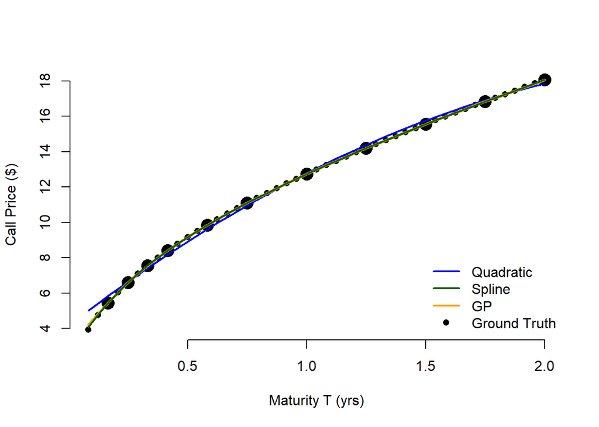

```r
seqT <- seq(1/12.0, 2.0, by=1/24.0)  # test set of maturities

plot(seqT, df_Calls[,25],
      bty='n', xlab="Maturity T (yrs)", ylab="Call Price ($)", pch=16)
points(train.design[,"T"], train.design[,"P"], col="black", pch=16, cex=2)
betas <- coef(quad.model)
lines(seqT, betas[1] + betas[2]*seqT + betas[3]*seqT^2, col="blue", lwd=2 )

# Predict from the fitted GPR model
PriceTest <-  predict(gpModel_Heston1D, newdata=data.frame(T=seqT), type="UK")
lines(seqT, PriceTest$mean, col="orange", lwd=3)
lines(seqT, predict(cubic.spl,newdata = list(T=seqT)), col="darkgreen", lwd=2)
legend("bottomright", c("Quadratic", "Spline", "GP", "Ground Truth"),  lwd=c(2,2,2,-1),
       pch=c(-1, -1, -1, 16), col=c( "blue", "darkgreen","orange", "black"), bty='n')
```

In the second plot (right panel of Figure 5.1) we zoom-in to show the differences between the surrogate-predicted option price and the ground truth on the test set:

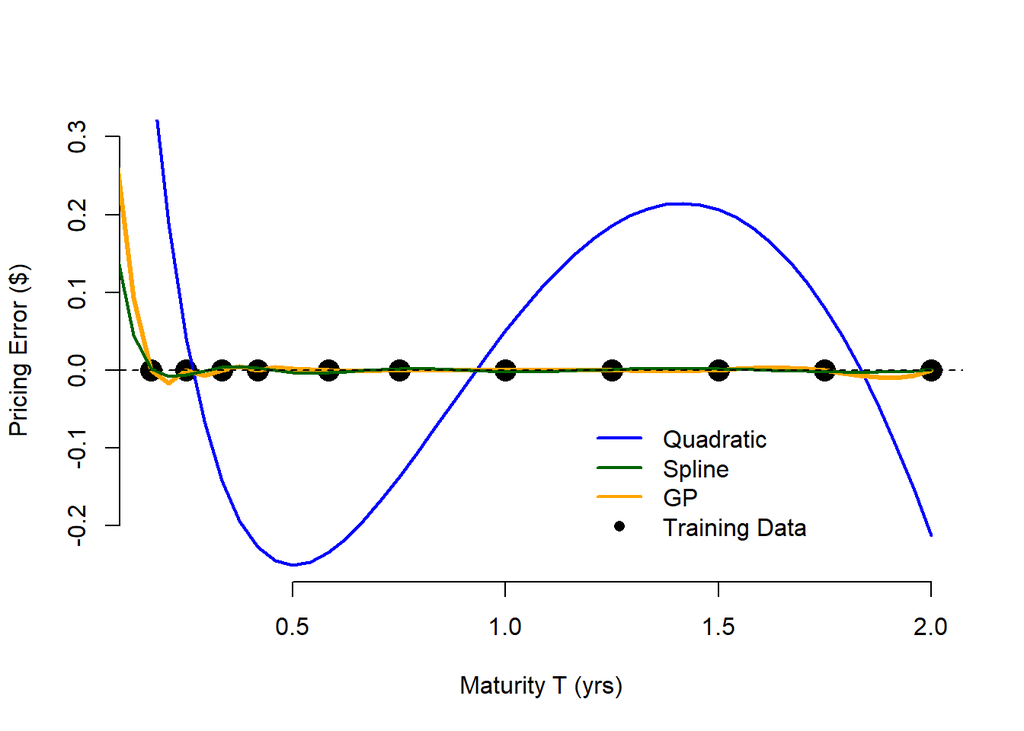

```r
plot(train.design[,"T"], rep(0, length(train.set)), col="black", pch=16, cex=2,
     ylim=c(-0.25, 0.3), bty='n', xlab="Maturity T (yrs)", ylab="Pricing Error ($)")
betas <- coef(quad.model)
lines(seqT, betas[1] + betas[2]*seqT + betas[3]*seqT^2 - df_Calls[,25], col="blue", lwd=2 )
lines(seqT, PriceTest$mean - df_Calls[,25], col="orange",lwd=3)
lines(seqT, predict(cubic.spl,newdata = list(T=seqT))-df_Calls[,25],col="darkgreen",lwd=2)
legend(x=1.2, y=-0.05, c("Quadratic", "Spline", "GP", "Training Data"), lwd=c(2,2,2,-1),
       pch=c(-1, -1, -1, 16), col=c( "blue", "darkgreen","orange", "black"), bty='n')
abline(h=0,lty=2)
```

# Learning the Black-Scholes Prices and Greeks

In the second case study, we work with the Black-Scholes model that postulates Geometric Brownian Motion dynamics for the univariate underlying asset price $(S_t)$:
$$dS_t = (r-q) S_t dt + \sigma S_t dW_t,$$
where $(W_t)$ is a Wiener process with respect the pricing measure $Q$, and the interest rate $r$, dividend yield $q$, and volatility $\sigma$ are given constants. We again consider the Call payoff $G(S_T) = \max(S_T-{\cal K},0)$ whose value admits an explicit representation given by the Black-Scholes formula. Taking partial derivatives of the Black-Scholes formula, one can obtain the related sensitivities or Greeks, in particular Delta ($\partial_P/\partial S$), Theta ($-\partial_P/\partial t$) and Gamma ($\partial^2 P/\partial S^2$).

The helper function implements the Black-Scholes formula and related Greeks:

```r
BScall <- function(t=0,T,S,K,r,q=0,sigma,isPut=0) {
# t and T are measured in years; all parameters are annualized
# r is the cont interest rate; q is the continuous dividend yield
# isPut=0: Call payoff; isPut=1: Put payoff
d1 <- (log(S/K)+(r-q+sigma^2/2)*(T-t))/(sigma*sqrt(T-t))
d2 <- d1-sigma*sqrt(T-t)

# Call Greeks at t
Delta <- exp(-q*(T-t))*pnorm(d1)
Gamma <- exp(-q*(T-t))*exp(-d1^2/2)/sqrt(2*pi)/S/sigma/sqrt(T-t)
Vega <- S*exp(-q*(T-t))/sqrt(2*pi)*exp(-d1^2/2)*sqrt(T-t)
Theta <- -S*exp(-q*(T-t))*sigma/sqrt(T-t)/2*dnorm(d1) - r*K*exp(-r*(T-t))*pnorm(d2) +
    q*S*exp(-q*(T-t))*pnorm(d1)
Rho <- (T-t)*K*exp(-r*(T-t))*pnorm(d2)

# Black-Scholes formula for Calls G(S_T) = (S_T-{\cal K})_+
BSprice <- S*Delta-K*exp(-r*(T-t))*pnorm(d2)

# Respective equations if the payoff is a Put, G(S_T) = ({\cal K}-S_T)_+
if (isPut == 1) {
    Delta <- -exp(-q*(T-t))*pnorm(-d1)
    BSprice <- S*Delta+K*exp(-r*(T-t))*pnorm(-d2)
    Theta <- -S*exp(-q*(T-t))*sigma/sqrt(T-t)/2*dnorm(d1) +
      r*K*exp(-r*(T-t))*pnorm(-d2) - q*S*exp(-q*(T-t))*pnorm(-d1)
    Rho <- -(T-t)*K*exp(-r*(T-t))*pnorm(-d2)
}

return (list(Delta=Delta,Gamma=Gamma,Theta=Theta,Vega=Vega,Rho=Rho,Price=BSprice))
}
```

We will train a 2D GP surrogate that learns to price Calls as a function of initial stock price $S_0$ and Call maturity $T$. For visualization purposes, we will test on a univariate test set with a fixed $T=0.5$.

```r
set.seed(2024)
xTest <- seq(60,130,by=1);  # test set to be plotted: moneyness in [0.6, 1.3]
tTest = 0.5;                # fixed test maturity
r <- 0.05; q <- 0.01        # interest rate and div yield
```

To generate training data, we rely on a vanilla Monte Carlo simulator that approximates option prices as empirical average of discounted payoffs. The simulator returns both the training output $y(x)$, as well as the corresponding noise variance $\sigma^2(x)$ (via the empirical MC variance).

```r
# generate data from a noisy Black-Scholes option pricer that
# utilizes vanilla Monte Carlo estimation based on M paths
BS_mc <- function(M, r=0.05, q=0, sigma=0.2, T=1, K = 100, S0=100)
{
  Z <- rnorm(M)

  S_T <- S0*exp( (r-q-sigma^2/2)*T + sigma*sqrt(T)*Z)  # terminal values
  Payoff <- exp(-r*T)*pmax(S_T -K, 0)   # discounted payoffs
  return( list(mean=  mean(Payoff), sd= sd(Payoff)/sqrt(M) ) )

}
```

We proceed to learn the Prices and the Greeks of a **Call option** with fixed strike ${\cal K}=100$. To do so, we employ a two-dimensional training set of 450 total training locations, with 400 actual inputs plus another 50 “virtual” inputs to capture the boundary conditions. Our task is to learn the Delta/Theta/Gamma of a Call as a function of current stock price $S_t$ (henceforth the spot) and time $t$. The inputs themselves are in the rectangle $[60,130] \times [0.05, 0.6]$.

The 400 training input-output tuples are constructed by sampling 400 locations via the space-filling Halton sequence (available in `randtoolbox` package) and then running Monte Carlo approximation of the respective option price through a plain Monte Carlo draw of $M'=2500$ i.i.d. samples based on the log-normal law of $S_T$ (this simulation engine is viewed as a black-box for the modeler). We then record the mean $\bar{y}^i$ and the standard deviation of these $M'$ samples.

```r
N_tr <- 450
hltn <- halton(400, dim=2)  # space-filling QMC sequence on [0,1] x [0,1]

# create simulation design rescaled to (t,x) \in [0.05, 0.6] x [60, 130]
simDsgn <- cbind(t=c(0.05+0.55*hltn[,1],rep(0,50)),
               spot=c(60+70*hltn[,2],rep(50,50)),
               price=rep(0,N_tr), noise=rep(0,N_tr) )

for (i in 1:(N_tr-50)) {
  mcPrice <- BS_mc(2500,K=100,r=0.05, q=0.01, sigma=0.2,
                     T=simDsgn[i,"t"], S0=simDsgn[i,"spot"])
  simDsgn[i,"price"] <- mcPrice$mean
  simDsgn[i,"noise"] <- mcPrice$sd
}
```

The next snippet creates 50 additional “virtual” training points at the edges of the above training set, namely 20 deep in-the-money ($S \in \{135,136\}$), 20 deep out-of-the-money $S \in \{54, 55\}$) and 10 training points at maturity to capture the final payoff shape.

```r
tSeq <- seq(0.02,0.6,len=10)
simDsgn[(N_tr-39):(N_tr),"t"] <- rep(tSeq,4)
simDsgn[(N_tr-49):(N_tr),"noise"] <- 0

# Calls have intrinsic value e^{-q T}S_0 - e^{-r T}K deep in-the-money
simDsgn[(N_tr-9):(N_tr),"price"] <- exp(-q*tSeq)*135-exp(-r*tSeq)*100
simDsgn[(N_tr-9):(N_tr),"spot"] <- 135

simDsgn[(N_tr-19):(N_tr-10),"price"] <- exp(-q*tSeq)*136-exp(-r*tSeq)*100
simDsgn[(N_tr-19):(N_tr-10),"spot"] <- 136

# Calls are worth zero deep out-of-the-money
simDsgn[(N_tr-29):(N_tr-20),"price"] <- 0
simDsgn[(N_tr-29):(N_tr-20),"spot"] <- 55

simDsgn[(N_tr-39):(N_tr-30),"price"] <- 0
simDsgn[(N_tr-39):(N_tr-30),"spot"] <- 54

# When T=0, the Call value is the payoff
simDsgn[(N_tr-49):(N_tr-40),"t"] <- 0
simDsgn[(N_tr-49):(N_tr-40),"spot"] <- seq(61,129,len=10)
simDsgn[(N_tr-49):(N_tr-40),"price"] <- pmax(0, simDsgn[(N_tr-49):(N_tr-40),"spot"]-100)
```

The Figure below visualizes the overall training set, showing the 400 MC-based inputs (in black) and the 50 virtual training points around the edges (in red).

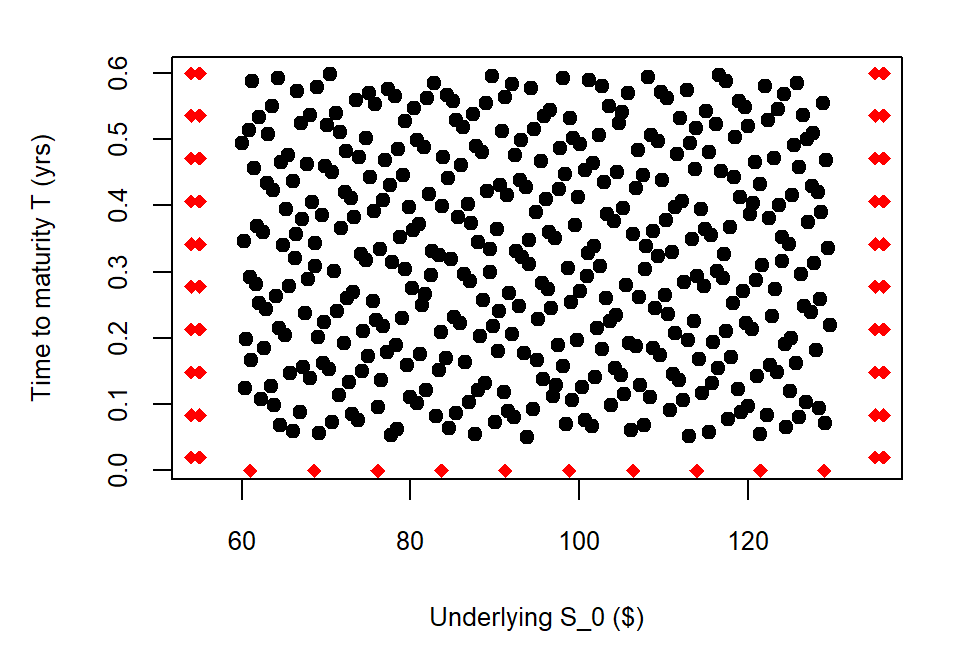

## Training the GP surrogate

With the training set of approximate option prices constructed, we are ready to train a GP surrogate. We generate two different models, one with a anisotropic SE kernel $k_{SE}$ and a second with a Matern kernel $k_{M52}$. For both cases we use a prior mean function of the form $\mu(S)= \beta_0 + \beta_1 S$.

```r
gpModel_M52 <- km(   formula = y ~ 1 + spot,  # linear trend function
                 design =simDsgn[,1:2],  response=simDsgn[,"price"],
                 nugget.estim=TRUE,  # learn
                 # alternatively: use the estimated simulation noise
                 #noise.var=pmax(1e-7, simDsgn[,"noise"]),
                 covtype="matern5_2",   # can also try "gauss" or "matern3_2"
                 optim.method="gen",
                 estim.method = "MLE",
                 lower=c(0.1,10), upper=c(2,100),  # bounds on lengthscales
                 # the "control" parameters below handle speed versus risk of
                 # converging to local minima.  See "rgenoud" package for details
                 control=list(max.generations=100,pop.size=100,
                              wait.generations=8,
                              solution.tolerance=1e-5,
                              maxit = 1000, trace=F
                 ))
print(coef(gpModel_M52))
```

```
## $trend1
## [1] -28.09959
##
## $trend2
## [1] 0.4584299
##
## $range
## [1]  1.074271 26.519040
##
## $shape
## numeric(0)
##
## $sd2
## [1] 29.72628
##
## $nugget
## [1] 0.02412824
```

```r
gpModel_SE <- km(   formula = y ~ 1 + spot,  # linear trend function
                 design =simDsgn[,1:2],  response=simDsgn[,"price"],
                 nugget.estim=TRUE,  # learn
                 # alternatively: use the estimated simulation noise
                 #noise.var=pmax(1e-7, simDsgn[,"noise"]),
                 covtype="gauss",
                 optim.method="gen",
                 estim.method = "MLE",
                 lower=c(0.1,10), upper=c(2,100),  # bounds on lengthscales
                 # the "control" parameters below handle speed versus risk of
                 # converging to local minima.  See "rgenoud" package for details
                 control=list(max.generations=100,pop.size=100,
                              wait.generations=8,
                              solution.tolerance=1e-5,
                              maxit = 1000, trace=F
                 ))
print(coef(gpModel_SE))
```

```
## $trend1
## [1] -29.99753
##
## $trend2
## [1] 0.4566741
##
## $range
## [1]  0.9173064 14.0468123
##
## $shape
## numeric(0)
##
## $sd2
## [1] 36.12261
##
## $nugget
## [1] 0.02494027
```

To compare the results we build a one-dimensional test set that uses a fixed time-to-maturity $\tau=0.5$ and a range of initial stock prices $S_0$.

```r
testSet <- data.frame(t=rep(tTest,length(xTest)),spot=xTest)

# Predict option prices using the GP surrogates
PriceTest_SE <-   predict(gpModel_SE, newdata=testSet,type="UK")
PriceTest_M52 <-  predict(gpModel_M52,newdata=testSet,type="UK")
```

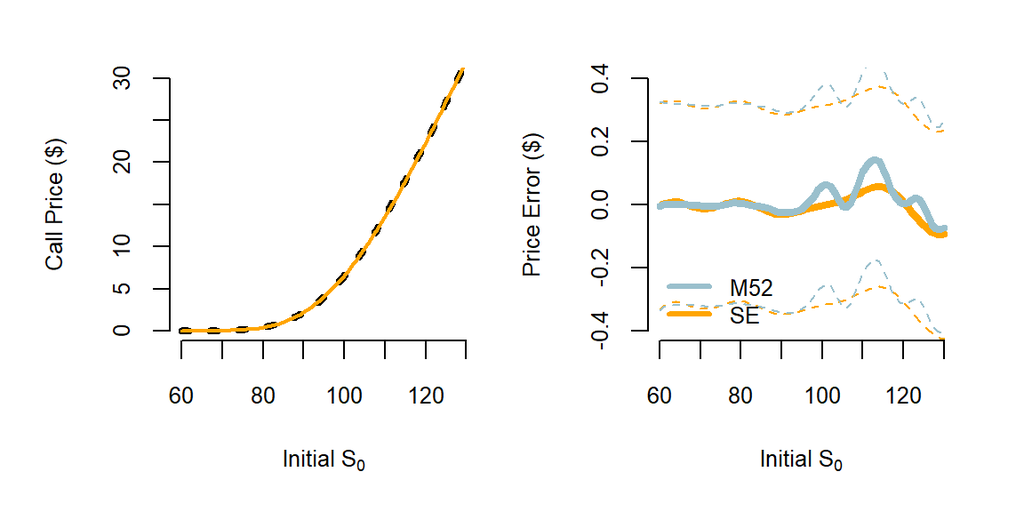

```r
par(mar = c(4,4,1,1),oma = c(1, 1, 1, 1),mfrow=c(1,2))
truePrice <- BScall(t=0, T=0.5, S=xTest, K=100, r=0.05, q=0.01, sigma=0.2, isPut=0)$Price
plot(xTest,truePrice, col="black", type="l", lwd=4, lty=3, cex.lab=0.8, cex.axis=0.8,
     xlab=expression(paste('Initial ', S[0])), ylab='Call Price ($)', bty='n', ylim=c(0,30))
lines(xTest,PriceTest_SE$m, lwd=2, col="orange")

#To better see the difference: show difference to ground truth

plot(xTest,truePrice-PriceTest_SE$m, col="orange", type="l", lwd=4, cex.lab=0.8, cex.axis=0.8,
     xlab=expression(paste('Initial ', S[0])), ylab='Price Error ($)', bty='n', ylim=c(-0.4, 0.4))
lines(xTest,truePrice-PriceTest_M52$m,col="lightblue3",lwd=4)
# also draw the 95% credible bands
lines(xTest,truePrice-PriceTest_SE$m+1.96*PriceTest_SE$sd, col="orange",lwd=1,lty=2)
lines(xTest,truePrice-PriceTest_SE$m-1.96*PriceTest_SE$sd, col="orange",lwd=1,lty=2)
lines(xTest,truePrice-PriceTest_M52$m+1.96*PriceTest_M52$sd, col="lightblue3",lwd=1,lty=2)
lines(xTest,truePrice-PriceTest_M52$m-1.96*PriceTest_M52$sd, col="lightblue3",lwd=1,lty=2)

legend("bottomleft",c("M52", "SE"),col=c("lightblue3","orange"),lwd=3, bty='n', cex=0.8)
```

# GP inference for the Greeks: Section 5.3

We next use the GP model to generate the posterior mean/variance of the gradients of `gpModel`. This involves differentiating the respective kernels to obtain the GP for the respective gradients. For Delta and Theta, we utilize the helper `gpDerivative` function that implements formulas (5.9)-(5.12) for the gradients of the Squared-Exponential and Matern-5/2 kernels.

```r
gpDerivative <- function(fit,xstar,i=2,K_Inv=0){
  # fit is a km object
  #   - requires Gaussian kernel or Matern 5-2
  # xstar is the test set
  # i indicates which coordinate the derivative should be taken in
  #   by default i=2
  # K_Inv is the inverse of the covariance matrix.  It can be given
  #   to reduce computational cost, if it has already been
  #   inverted.  Otherwise, it pulls Delta from the km object
  #   and inverts it.
  # Returns a posterior mean and posterior covariance for the
  #  distribution evaluated at xstar.

  xstar <- as.matrix(xstar)
  y <- fit@y
  x <- fit@X
  eta2 <- fit@covariance@sd2
  theta <- fit@covariance@range.val[i]
  c.1 <- covMatrix(fit@covariance,xstar)$C - covMatrix(fit@covariance,xstar)$vn
  c.2 <- covMat1Mat2(fit@covariance,xstar,x, nugget.flag=FALSE)
  if(K_Inv == 0){
    # T is the Choleski decomposition of the covariance matrix
    T <- fit@T
    Delta <- t(T) %*% T
    K_Inv <- solve(Delta)
  }

  # derivative of the squared-exponential kernel
  if(fit@covariance@name == "gauss"){
    dcxx <- -1 / theta ^ 2 * outer(xstar[, i], xstar[, i], '-') * c.1
    d2c <- 1 / theta ^ 2 * (-c.1 + outer(xstar[, i], xstar[, i], '-') * dcxx)
    dcxX <- -1 / theta ^ 2 * outer(xstar[, i], x[, i], '-') * c.2
    dcXx <- -1 / theta ^ 2 * outer(x[, i], xstar[, i], '-') * t(c.2)

    covDiag <- sqrt(pmax(0, -diag(d2c - dcxX %*% K_Inv %*% dcXx)))
  }

  # derivative of the Matern-4/2 kernel
  if(fit@covariance@name == "matern5_2"){

    absDist <- abs(outer(xstar[,i],x[,i],'-') )
    leadTerm1 <- 1 + sqrt(5)/theta*absDist + 5/3/theta^2*absDist*absDist
    numTerm1 <- -5/3/theta^2*outer(xstar[,i],x[,i],'-')-sqrt(5)*5/3/theta^3*absDist*outer(xstar[,i],x[,i],'-')
    dcxX <- numTerm1/leadTerm1* c.2

    dcXx <- t(dcxX)

    covDiag = sqrt(diag( 5/3/theta^2*c.1 - dcxX %*% K_Inv %*% dcXx))
  }

  # de-trend the mean. Hard-coded about regressing on 1+spot
  detr_y <- fit@y - fit@F %*% fit@trend.coef
  m <- dcxX %*% K_Inv %*% detr_y

  if (i == 2 & length(fit@trend.coef) == 2)
    m <- m + fit@trend.coef[2]

  return(list(m=m,covmat=covDiag))  # only compute the standard errors at x_star, no covariances

}
```

We use the above function to compute the Call Delta and Theta for the test points based on the two above GP models.

```r
# Delta: gradient with respect to x_2
DeltaTest_SE <- gpDerivative(fit=gpModel_SE, testSet,i=2)
DeltaTest_M52 <- gpDerivative(fit=gpModel_M52, testSet,i=2)

# Theta -- gradient with respect to x_1
ThetaTest_SE <- gpDerivative(fit=gpModel_SE,testSet,i=1)
ThetaTest_M52 <- gpDerivative(fit=gpModel_M52,testSet,i=1)
```

To compute second order sensitivity, specifically option Gamma, we employ finite differences (to demonstrate that this is also a quick-to-implement alternative):
$$\frac{\partial^2 P}{\partial S^2}(t,S)\simeq
\frac{P(t,S+h)-2P(t,S)+P(t,S-h)}{h^2}.$$
Below we set discretization parameter $h=0.01$.

```r
h <- 0.01  # h for finite-differencing approximation
GammaTest_M52 <- GammaTest_SE <- xTest  # evaluate one predictive site at a time
for (jj in 1:length(xTest)) {
  GammaTriple <- data.frame(spot=c(xTest[jj]-h,xTest[jj],xTest[jj]+h),
                                                 t=c(tTest,tTest,tTest))
  triple <-  predict(gpModel_M52,newdata=GammaTriple,type="UK")$mean
  GammaTest_M52[jj] <- (triple[3]-2*triple[2]+triple[1])/h^2  # Gamma approximation
  triple <-  predict(gpModel_SE,newdata=GammaTriple,type="UK")$mean
  GammaTest_SE[jj] <- (triple[3]-2*triple[2]+triple[1])/h^2
}
```

We now plot the Greeks and their posterior uncertainty (credible bands, shown at 95% level). This is equivalent to the plots in **Figure 5.2** of the book. Observe that the estimate of Gamma is not stable using the M52 kernel (which is only twice-differentiable, while SE is infinitely-differentiable).

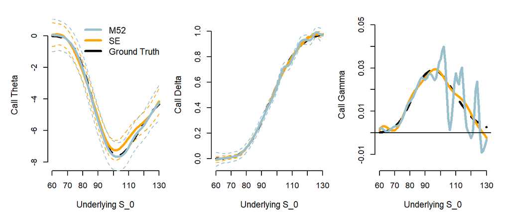

```r
par(mar = c(4,4,1,1),oma = c(1, 1, 1, 1), mfrow=c(1,3))
# Theta panel
plot(xTest,BScall(T=0.5, S=xTest, K=100, r=0.05, q=0.01, sigma=0.2, isPut=0)$Theta,
     col="black",type="l", lwd=3, lty=2,  cex.lab=1.1, # ground truth
     xlab='Underlying S_0', ylab='Call Theta', bty='n', ylim=c(-8.2,0.7))
lines(xTest,-ThetaTest_SE$m, lwd=3, col="orange")
lines(xTest,-ThetaTest_SE$m+1.96*ThetaTest_SE$covmat, col="orange",lwd=1,lty=2)
lines(xTest,-ThetaTest_SE$m-1.96*ThetaTest_SE$covmat, col="orange",lwd=1,lty=2)

lines(xTest,-ThetaTest_M52$m, lwd=3, col="lightblue3")
lines(xTest,-ThetaTest_M52$m+1.96*ThetaTest_M52$covmat, col="lightblue3",lwd=1,lty=2)
lines(xTest,-ThetaTest_M52$m-1.96*ThetaTest_M52$covmat, col="lightblue3",lwd=1,lty=2)
legend("topright",c("M52", "SE", "Ground Truth"),
       col=c("lightblue3","orange", "black"), lwd=3, bty='n',cex=1.1)

# Delta panel
plot(xTest,BScall(T=0.5, S=xTest, K=100, r=0.05, q=0.01, sigma=0.2, isPut=0)$Delta,
     col="black",type="l", lwd=3, lty=2, cex.lab=1.1,
     xlab='Underlying S_0', ylab='Call Delta', bty='n', ylim=c(-0.05,1.05))

lines(xTest,DeltaTest_SE$m, lwd=3, col="orange")
lines(xTest,DeltaTest_SE$m+1.96*DeltaTest_SE$covmat, col="orange",lwd=1,lty=2)
lines(xTest,DeltaTest_SE$m-1.96*DeltaTest_SE$covmat, col="orange",lwd=1,lty=2)

lines(xTest,DeltaTest_M52$m, lwd=3, col="lightblue3")
lines(xTest,DeltaTest_M52$m+1.96*DeltaTest_M52$covmat, col="lightblue3",lwd=1,lty=2)
lines(xTest,DeltaTest_M52$m-1.96*DeltaTest_M52$covmat, col="lightblue3",lwd=1,lty=2)

# Gamma panel
plot(xTest,BScall(T=0.5, S=xTest, K=100, r=0.05, q=0.01, sigma=0.2, isPut=0)$Gamma,
     col="black",lwd=3, lty=2, type="l", bty='n',ylim=c(-0.015, 0.05),
     xlab='Underlying S_0', ylab='Call Gamma', cex.lab=1.1
)
lines(xTest,GammaTest_SE,type="l", lwd=3, col="orange")
lines(xTest,GammaTest_M52,lwd=3,col="lightblue3")
abline(h=0)
```